# Data Visualisation - Assignement 2

Alice Emily Baird (aeb2238)

1 March 2015

To recreate a data visualisation http://www.informationisbeautiful.net/visualizations/the-microbescope/

**Set Up** *set up including directory and loading the ggplot2 library.*

```r
library(ggplot2)

#if required set directory and then load data
setwd("~/data-viz/ebola")
microbe_data <- read.csv(file="Microbe-scope-bugs.csv", header=TRUE)
```

**Clean** *clean and convert the data*

```r
#changes names of deseases according to graph.
microbe_data[,1] <- as.character(microbe_data[,1])
microbe_data[2,1] <- "Avian Flu (H5N1)"

microbe_data[3,1] <- "Bubonic Plague"
microbe_data[14,1] <- "HIV\nuntreated"
microbe_data[18,1] <- "Malaria"
microbe_data[23,1] <- "Norovirus\n'vomiting bug'"
microbe_data[27,1] <- "Rabies\nuntreated"
microbe_data[28,1] <- "Rhinovirus\ncommom cold"
microbe_data[29,1] <- "Rotavirus\n'stomach bug'"
microbe_data[37,1] <- "Syphilis"
microbe_data[38,1] <- "Tuberculosis"
microbe_data[24,1] <- "Whooping Cough"


#remove unnessary columns

names(microbe_data)[1]<-"microbe_data"
script <-microbe_data [1, ]
microbe_data <- microbe_data[-1, ]
script <- grep(pattern="note", x=names(microbe_data), ignore.case=TRUE)
microbe_data <- subset(microbe_data, select = -script)

# no % values



prcno<-function(df, var){
      prcno<-strsplit(as.character(df[[var]]), split="%")
     df[[var]]<-as.numeric(prcno)
     return(df[[var]])
}

# remove % signs, leaving a numeric value.
microbe_data[["case.fatality.rate"]]<-prcno(microbe_data, "case.fatality.rate")

microbe_data$average.basic.reproductive.rate <- as.numeric(as.character(microbe_data$average.basic.reproductive.rate))

# remove specific unwanted data
microbe_data <- subset(microbe_data, microbe_data != "Malaria (P. falciparum)")

microbe_data <- subset(microbe_data, primary.mode.of.transmission != "")

microbe_data <- microbe_data[,c(1:4)]

# remove copied data
microbe_data$microbe_data<- as.character(microbe_data$microbe_data)
microbe_data$microbe_data[1] <- "Bird Flu (H5N1) & Bubo. Pla. (untrd)"
microbe_data$microbe_data[2] <- "Bird Flu (H5N1) & Bubo. Pla. (untrd)"
microbe_data$microbe_data[25] <- "Rhinovirus & Rubella"
microbe_data$microbe_data[27] <- "Rhinovirus & Rubella"

microbe_data <- microbe_data[complete.cases(microbe_data),]


#change all airborn droplets to airborn as they have in graph

microbe_data[1,4] <-"airborne"
microbe_data[5,4] <-"airborne"
microbe_data[13,4] <-"airborne"
microbe_data[18,4] <-"airborne"
microbe_data[20,4] <-"airborne"
microbe_data[22,4] <-"airborne"
microbe_data[26,4] <-"airborne"
microbe_data[28,4] <-"airborne"
microbe_data[30,4] <-"airborne"
microbe_data[32,4] <-"airborne"
microbe_data[33,4] <-"airborne"
microbe_data[34,4] <-"airborne"
microbe_data[36,4] <-"airborne"
microbe_data[38,4] <-"airborne"
```

**Plot** plotting with the ggplot commands.including:  
set increase x axis scale to show - values

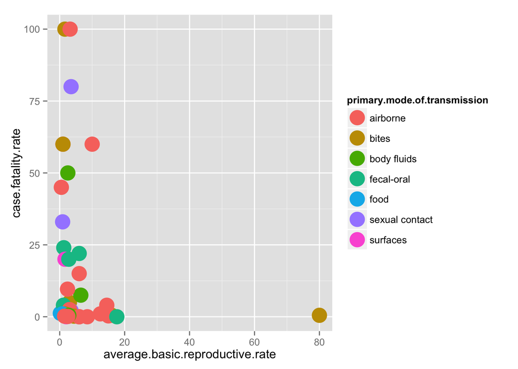

```r
p <- ggplot(microbe_data, aes(x=average.basic.reproductive.rate, y=case.fatality.rate, group =primary.mode.of.transmission, colour=primary.mode.of.transmission)) +
        geom_point(size=7)
print(p)
```

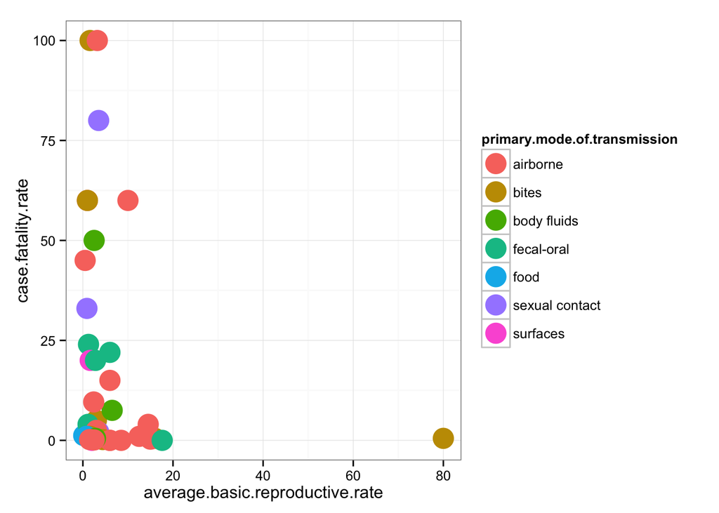

```r
#set a theme

p <- p + theme_bw ()
print(p)
```

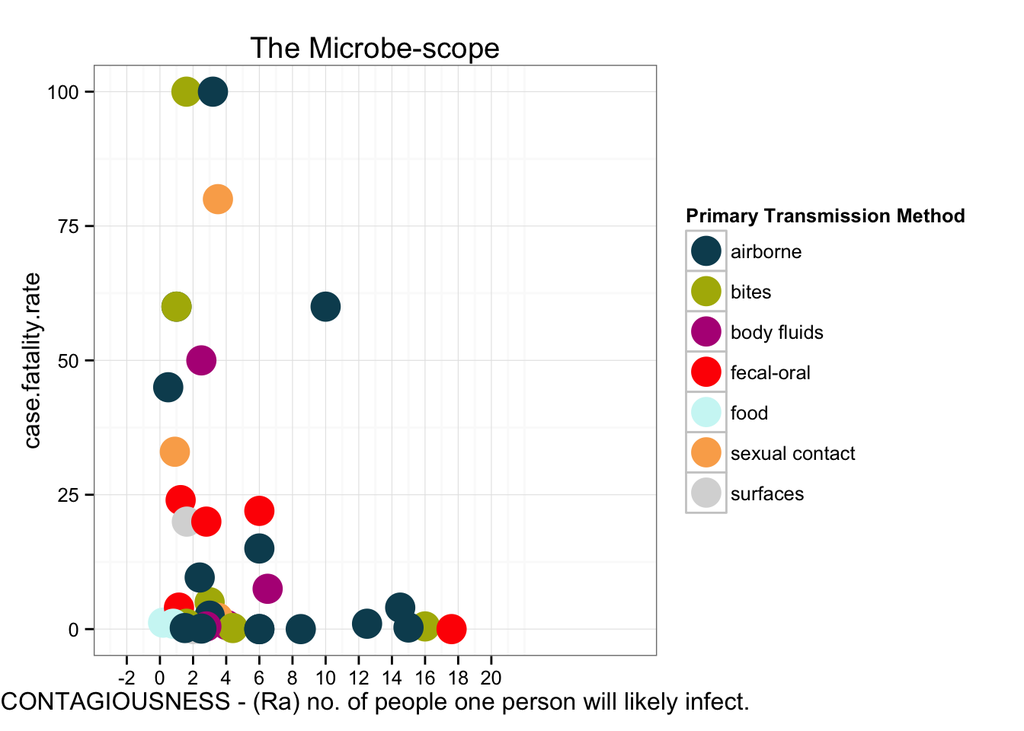

```r
#colours and title (including increase x scale value)

p <- p + scale_color_manual(values =c("#0B4C5F", "#AEB404", "#B40486", "red", "#CEF6F5", "#FAAC58", "#D8D8D8"),name="Primary Transmission Method") +
        ggtitle("The Microbe-scope") +
          scale_x_continuous("CONTAGIOUSNESS - (Ra) no. of people one person will likely infect.", limits=c(-4, 30), breaks=c(-2, 0,2,4,6,8,10,12,14,16,18,20), expand = c(0,0))

print(p)
```

**Modify** *As there is confusing cluster around 0 of the y axis I’m using the log function to pull the data out and make a non continuous stream.*

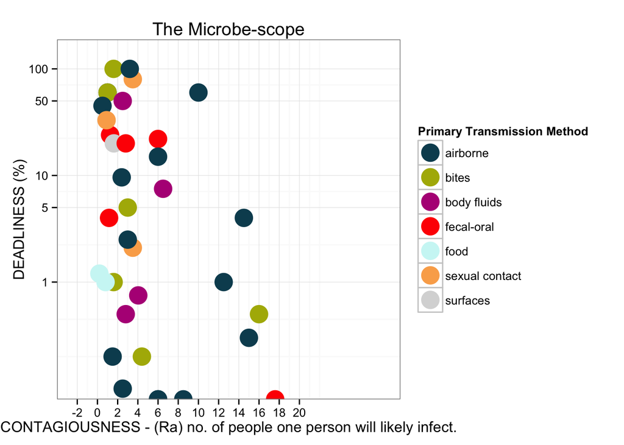

```r
#Modify y axis


p <- p + scale_y_log10("DEADLINESS (%)", limits = c(0.1,150), breaks =c(0.001, 0.05,1,5, 10, 50, 100), labels = c(0.001, 0.05, 1,5, 10,50,100), expand = c(0,0.1))
print(p)
```

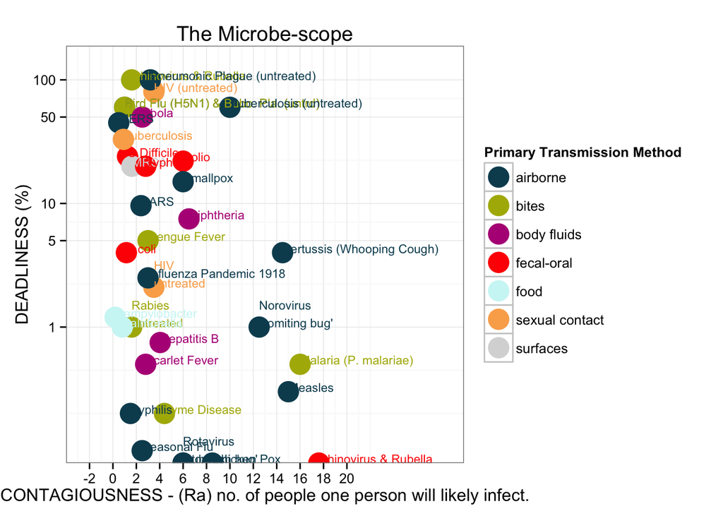

```r
# Label the blobs

p <- p+ geom_text(aes(label = microbe_data, hjust = 0, vjust=0, angle = 0), size=3)
print(p)
```

**Annotate** *annotate the grid shade in the sections.*

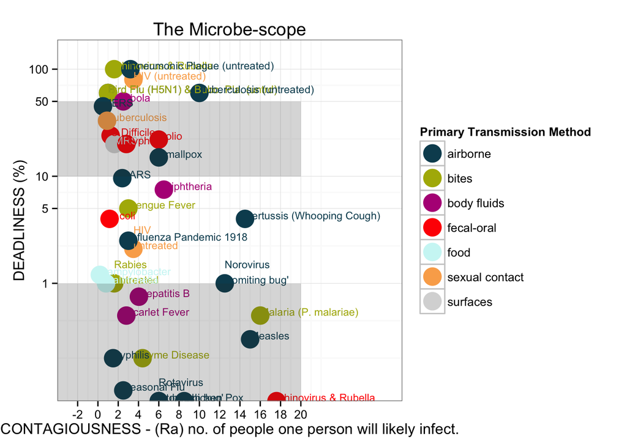

```r
#large squares
p <- p+ annotate("rect", xmin = -4, xmax = 20, ymin = 10, ymax = 50,
        alpha = .2) +
        annotate("rect", xmin = -4, xmax = 20, ymin = 0, ymax = 1,
        alpha = .2)
print(p)
```

*add the lines*

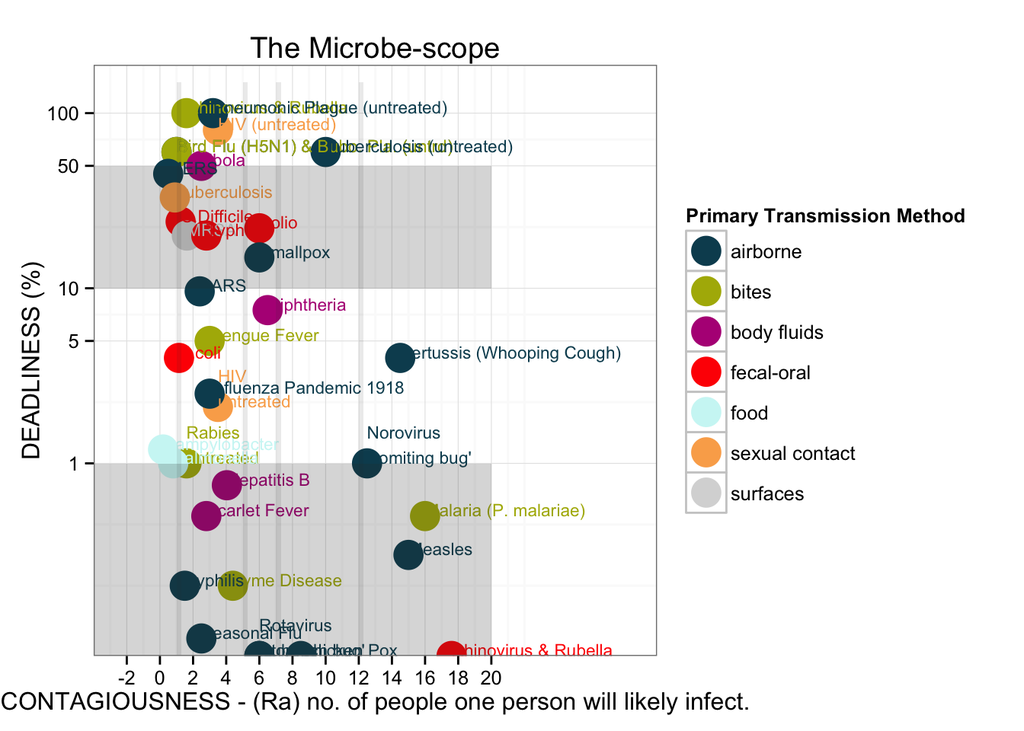

```r
#lines vertical
p <- p+ annotate("rect", xmin = 1, xmax = 1.3, ymin = 0, ymax = 150,
        alpha = .1) +
        annotate("rect", xmin = 5, xmax = 5.3, ymin = 0, ymax = 150,
        alpha = .1) +
        annotate("rect", xmin = 7, xmax = 7.3, ymin = 0, ymax = 150,
        alpha = .1) +
        annotate("rect", xmin = 12, xmax = 12.3, ymin = 0, ymax = 150,
        alpha = .1)

print(p)
```

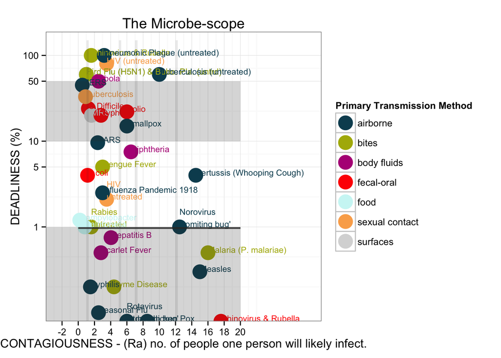

```r
#line horizontal
p <- p+ annotate("rect", xmin = 0, xmax = 20, ymin = 0.95, ymax = 1.,
        alpha = 0.8)

print(p)
```

*and the x and y axis text*

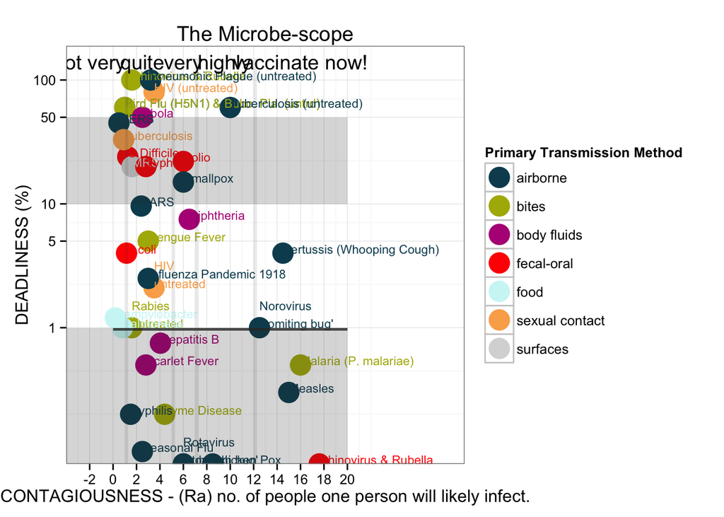

```r
#top text
p <- p + annotate("text", x = -2, y = 140, label = "not very") +
        annotate("text", x = 2.5, y = 140, label = "quite") +
  annotate("text", x = 6, y = 140, label = "very") +
  annotate("text", x = 9.5, y = 140, label = "highly") +
  annotate("text", x = 16, y = 140, label = "vaccinate now!")

print(p)
```

```r
#right text
p <- p + annotate("text", x = 23, y = 75, label = "extremely deadly") +
    annotate("text", x = 23, y = 25, label = "deadly") +
    annotate("text", x = 23, y = 2.5, label = "quite deadly") +
    annotate("text", x = 23, y = 0.25, label = "not too deadly")

print (p)
```

[output not shown]

```
## Warning: Removed 2 rows containing missing values (geom_point).
```

```
## Warning: Removed 2 rows containing missing values (geom_text).
```

[figure not shown]

I found this task really challenging…I’d like to know how I can widen the preview of my graph as in the html i feel it looks to clusterd and very confusing.  
I considered adding blank rows and columns but wasn’t sure if this was the right thing as I had already set a larger limit.

I also really wanted to change the text size for the annotations a long the top and side but I could work out how to alter the function.